# Stickiness metric

## Introduction

Longitudinal “stickiness” is the ratio of the number of students graduating in a program to the number of students ever enrolled in that program (Ohland et al., 2012).

The stickiness metric accounts for all students in a program. Unlike the graduation rate metric, stickiness includes students who begin college part-time, who enroll mid-year, and who switch majors or transfer between institutions.

Every student counted in a program’s stickiness metric was enrolled in that program for at least one term. The program succeeded in attracting these students—stickiness tells us how well the program succeeded in retaining them.

### This vignette uses

midfieldr functions

- `subset_feasible()`

data.table syntax

- `copy()` prevent changing a source by reference
- `DT[rows_we_want]` subset rows
- `DT[, .(new_col = .N), by = grouping_variables]` count N by group
- `DT[, new_col := FUN]` create new column as a function of old columns
- `DT[rows_to_edit, col := value]` for identified rows, assign value in column
- `DT[, .SD[col1 == min(col1)], by = col2]` retain rows of minimum values by group

packages

```r
# packages used
library(midfieldr)
library(midfielddata)
library(data.table)
library(ggplot2)

# print max 20 rows, otherwise 10 rows each head/tail
options(datatable.print.nrows = 20, datatable.print.topn = 10)
```

## Choose the programs to study

In the *Identify programs* vignette (link), we create the program group of 6-digit codes and user-defined program names for the engineering case study. These data are included with midfieldr as the built-in data set `rep_group`. View its help page by running

```r
? rep_group
```

The data are loaded with midfieldr.

```r
# obtain programs (built-in data set)
program_group <- copy(rep_group)

# examine the result
program_group
```

```
#>       cip6                program
#>  1: 140801      Civil Engineering
#>  2: 140802      Civil Engineering
#>  3: 140803      Civil Engineering
#>  4: 140804      Civil Engineering
#>  5: 140805      Civil Engineering
#>  6: 140899      Civil Engineering
#>  7: 141001 Electrical Engineering
#>  8: 141003 Electrical Engineering
#>  9: 141004 Electrical Engineering
#> 10: 141099 Electrical Engineering
#> 11: 141901 Mechanical Engineering
#> 12: 143501 Industrial Engineering
```

We extract the `cip6` column as a character vector to gather student data.

```r
# extract a vector of 6-digit CIP codes
group_cip <- program_group$cip6

# examine the result
group_cip
```

```
#>  [1] "140801" "140802" "140803" "140804" "140805" "140899" "141001" "141003"
#>  [9] "141004" "141099" "141901" "143501"
```

## Gather the students ever enrolled

We access `midfieldterms` to obtain the IDs of all students ever enrolled in these programs.

```r
# extract students ever enrolled
cols_we_want <- c("id", "cip6")
rows_we_want <- midfieldterms$cip6 %in% group_cip
enrollees <- midfieldterms[rows_we_want, ..cols_we_want]
enrollees <- unique(enrollees)

# examine the result
enrollees[order(id)]
```

```
#>                 id   cip6
#>     1: MID25783178 143501
#>     2: MID25783197 140801
#>     3: MID25783388 141901
#>     4: MID25783441 140801
#>     5: MID25783491 141001
#>     6: MID25783553 140801
#>     7: MID25783606 141001
#>     8: MID25783648 140801
#>     9: MID25783912 143501
#>    10: MID25784022 141901
#>    ---
#> 10755: MID26696484 141901
#> 10756: MID26696642 141001
#> 10757: MID26696738 141901
#> 10758: MID26696771 141001
#> 10759: MID26696958 141901
#> 10760: MID26696967 141901
#> 10761: MID26696979 141901
#> 10762: MID26697163 141901
#> 10763: MID26697444 141901
#> 10764: MID26697447 141001
```

There may be FYE students who are imputed to have started in one of these programs as well. In the *Handle FYE programs* vignette (link), we derive the starting programs for all FYE students in midfielddata. This `fye_start` data is included in midfieldr. Again, we filter by the program group CIP codes.

```r
# gather FYE students predicted to start in these programs
rows_we_want <- fye_start$start %in% group_cip
cols_we_want <- c("id", "start")
fye_starters <- fye_start[rows_we_want, ..cols_we_want]
fye_starters <- unique(fye_starters)
setnames(fye_starters, old = "start", new = "cip6")

# examine the result
fye_starters[order(id)]
```

```
#>                id   cip6
#>    1: MID25783166 141901
#>    2: MID25783227 141001
#>    3: MID25783388 141901
#>    4: MID25783428 140801
#>    5: MID25783441 140801
#>    6: MID25783491 141001
#>    7: MID25783553 140801
#>    8: MID25783606 141001
#>    9: MID25783648 140801
#>   10: MID25783753 141901
#>   ---
#> 3819: MID26648222 141901
#> 3820: MID26648282 143501
#> 3821: MID26648283 141001
#> 3822: MID26648334 140801
#> 3823: MID26648392 141901
#> 3824: MID26648422 141901
#> 3825: MID26648435 141901
#> 3826: MID26648484 140801
#> 3827: MID26648517 140801
#> 3828: MID26648544 141901
```

Bind the two data frames

```r
enrollees <- rbind(enrollees, fye_starters)
enrollees <- unique(enrollees)

# examine the result
enrollees[order(id)]
```

```
#>                 id   cip6
#>     1: MID25783166 141901
#>     2: MID25783178 143501
#>     3: MID25783197 140801
#>     4: MID25783227 141001
#>     5: MID25783388 141901
#>     6: MID25783428 140801
#>     7: MID25783441 140801
#>     8: MID25783491 141001
#>     9: MID25783553 140801
#>    10: MID25783606 141001
#>    ---
#> 12400: MID26696484 141901
#> 12401: MID26696642 141001
#> 12402: MID26696738 141901
#> 12403: MID26696771 141001
#> 12404: MID26696958 141901
#> 12405: MID26696967 141901
#> 12406: MID26696979 141901
#> 12407: MID26697163 141901
#> 12408: MID26697444 141901
#> 12409: MID26697447 141001
```

The enrollee data derived above is the data set `rep_ever` in midfieldr. View its help page by running

```r
? rep_ever
```

For some of these students, completing their program may not be feasible given the range of data available. `subset_feasible()` subsets the student IDs, retaining those who matriculate at least six years before the last term in the data.

```r
# apply the feasible completion filter
feasible_ids <- subset_feasible(id = enrollees$id)

# examine the result
str(feasible_ids)
```

```
#>  chr [1:9166] "MID25783178" "MID25783197" "MID25783441" "MID25783491" ...
```

See the *Feasible completion* vignette (link) for a detailed explanation of how completion feasibility is determined.

```r
# subset the enrollees
rows_we_want <- enrollees$id %in% feasible_ids
enrollees <- enrollees[rows_we_want]

# examine the result
enrollees[order(id)]
```

```
#>                id   cip6
#>    1: MID25783178 143501
#>    2: MID25783197 140801
#>    3: MID25783227 141001
#>    4: MID25783388 141901
#>    5: MID25783441 140801
#>    6: MID25783491 141001
#>    7: MID25783553 140801
#>    8: MID25783606 141001
#>    9: MID25783753 141901
#>   10: MID25783830 141901
#>   ---
#> 9764: MID26696439 141901
#> 9765: MID26696484 141901
#> 9766: MID26696642 141001
#> 9767: MID26696738 141901
#> 9768: MID26696771 141001
#> 9769: MID26696958 141901
#> 9770: MID26696967 141901
#> 9771: MID26697163 141901
#> 9772: MID26697444 141901
#> 9773: MID26697447 141001
```

We access `midfieldstudents` to obtain the race/ethnicity and sex of the enrollees.

```r
# obtain race/ethnicity and sex at matriculation
rows_we_want <- midfieldstudents$id %in% feasible_ids
cols_we_want <- c("id", "race", "sex")
race_sex <- midfieldstudents[rows_we_want, ..cols_we_want]
race_sex <- unique(race_sex)

# examine the result
race_sex[order(id)]
```

```
#>                id     race    sex
#>    1: MID25783178    Black   Male
#>    2: MID25783197    White   Male
#>    3: MID25783227    White   Male
#>    4: MID25783388    White   Male
#>    5: MID25783441    White   Male
#>    6: MID25783491    White   Male
#>    7: MID25783553    White   Male
#>    8: MID25783606    White   Male
#>    9: MID25783753    White   Male
#>   10: MID25783830    Black   Male
#>   ---
#> 9157: MID26696439    White   Male
#> 9158: MID26696484    White   Male
#> 9159: MID26696642    White   Male
#> 9160: MID26696738    White   Male
#> 9161: MID26696771    White Female
#> 9162: MID26696958    White   Male
#> 9163: MID26696967    White   Male
#> 9164: MID26697163 Hispanic   Male
#> 9165: MID26697444    White   Male
#> 9166: MID26697447    Asian   Male
```

Now we can join the race/ethnicity and sex data frame to the enrollees data frame.

```r
# left-join demographics to enrollees
enrollees <- merge(enrollees, race_sex, by = "id", all.x = TRUE)

# examine the result
enrollees[order(id)]
```

```
#>                id   cip6     race    sex
#>    1: MID25783178 143501    Black   Male
#>    2: MID25783197 140801    White   Male
#>    3: MID25783227 141001    White   Male
#>    4: MID25783388 141901    White   Male
#>    5: MID25783441 140801    White   Male
#>    6: MID25783491 141001    White   Male
#>    7: MID25783553 140801    White   Male
#>    8: MID25783606 141001    White   Male
#>    9: MID25783753 141901    White   Male
#>   10: MID25783830 141901    Black   Male
#>   ---
#> 9764: MID26696439 141901    White   Male
#> 9765: MID26696484 141901    White   Male
#> 9766: MID26696642 141001    White   Male
#> 9767: MID26696738 141901    White   Male
#> 9768: MID26696771 141001    White Female
#> 9769: MID26696958 141901    White   Male
#> 9770: MID26696967 141901    White   Male
#> 9771: MID26697163 141901 Hispanic   Male
#> 9772: MID26697444 141901    White   Male
#> 9773: MID26697447 141001    Asian   Male
```

We join the program names from `program_group` to our working data frame so we can aggregate by groups in a future step.

```r
# left-join program_group to enrollees
enrollees <- merge(enrollees, program_group, by = "cip6", all.x = TRUE)

# examine the result
enrollees[order(id)]
```

```
#>         cip6          id     race    sex                program
#>    1: 143501 MID25783178    Black   Male Industrial Engineering
#>    2: 140801 MID25783197    White   Male      Civil Engineering
#>    3: 141001 MID25783227    White   Male Electrical Engineering
#>    4: 141901 MID25783388    White   Male Mechanical Engineering
#>    5: 140801 MID25783441    White   Male      Civil Engineering
#>    6: 141001 MID25783491    White   Male Electrical Engineering
#>    7: 140801 MID25783553    White   Male      Civil Engineering
#>    8: 141001 MID25783606    White   Male Electrical Engineering
#>    9: 141901 MID25783753    White   Male Mechanical Engineering
#>   10: 141901 MID25783830    Black   Male Mechanical Engineering
#>   ---
#> 9764: 141901 MID26696439    White   Male Mechanical Engineering
#> 9765: 141901 MID26696484    White   Male Mechanical Engineering
#> 9766: 141001 MID26696642    White   Male Electrical Engineering
#> 9767: 141901 MID26696738    White   Male Mechanical Engineering
#> 9768: 141001 MID26696771    White Female Electrical Engineering
#> 9769: 141901 MID26696958    White   Male Mechanical Engineering
#> 9770: 141901 MID26696967    White   Male Mechanical Engineering
#> 9771: 141901 MID26697163 Hispanic   Male Mechanical Engineering
#> 9772: 141901 MID26697444    White   Male Mechanical Engineering
#> 9773: 141001 MID26697447    Asian   Male Electrical Engineering
```

## Gather the students graduating

We access `midfielddegrees` to obtain the IDs of all students graduating from these programs. We skip the feasible completion step because for graduates, the question of completion feasibility is moot—graduation itself establishes feasibility.

```r
# extract graduates
cols_we_want <- c("id", "cip6", "term_degree")
rows_we_want <- midfielddegrees$cip6 %in% group_cip
graduates <- midfielddegrees[rows_we_want, ..cols_we_want]

# examine the result
graduates[order(id)]
```

```
#>                id   cip6 term_degree
#>    1: MID25783178 143501       20001
#>    2: MID25783197 140801       19911
#>    3: MID25783441 140801       19963
#>    4: MID25783491 141001       20001
#>    5: MID25783912 143501       20001
#>    6: MID25784334 140801       19963
#>    7: MID25784418 140801       19981
#>    8: MID25784489 140801       19931
#>    9: MID25784709 140801       19971
#>   10: MID25784742 140801       19943
#>   ---
#> 4667: MID26696234 141901       20143
#> 4668: MID26696337 140801       20133
#> 4669: MID26696429 143501       20133
#> 4670: MID26696484 141901       20154
#> 4671: MID26696642 141001       20153
#> 4672: MID26696738 141901       20133
#> 4673: MID26696771 141001       20143
#> 4674: MID26696967 141901       20141
#> 4675: MID26697163 141901       20133
#> 4676: MID26697447 141001       20154
```

Some students might have earned a second degree in a term after their first degree. To ensure we count only the first degree, we the minimum value of `term_degree` grouped by `id`, using the data.table `.SD` syntax.

```r
# keep the first degree term if more than one
graduates <- graduates[, .SD[term_degree == min(term_degree)], by = id]

# examine the result
graduates[order(id)]
```

```
#>                id   cip6 term_degree
#>    1: MID25783178 143501       20001
#>    2: MID25783197 140801       19911
#>    3: MID25783441 140801       19963
#>    4: MID25783491 141001       20001
#>    5: MID25783912 143501       20001
#>    6: MID25784334 140801       19963
#>    7: MID25784418 140801       19981
#>    8: MID25784489 140801       19931
#>    9: MID25784709 140801       19971
#>   10: MID25784742 140801       19943
#>   ---
#> 4667: MID26696234 141901       20143
#> 4668: MID26696337 140801       20133
#> 4669: MID26696429 143501       20133
#> 4670: MID26696484 141901       20154
#> 4671: MID26696642 141001       20153
#> 4672: MID26696738 141901       20133
#> 4673: MID26696771 141001       20143
#> 4674: MID26696967 141901       20141
#> 4675: MID26697163 141901       20133
#> 4676: MID26697447 141001       20154
```

We can remove the `term_degree` column and then we access `midfieldstudents` for student race/ethnicity and sex.

```r
# finished with term_degree column
graduates[, term_degree := NULL]

# join race sex
rows_we_want <- midfieldstudents$id %in% graduates$id
cols_we_want <- c("id", "race", "sex")
race_sex <- midfieldstudents[rows_we_want, ..cols_we_want]
race_sex <- unique(race_sex)
graduates <- merge(graduates, race_sex, by = "id", all.x = TRUE)

# join program labels
graduates <- merge(graduates, program_group, by = "cip6", all.x = TRUE)

# examine the result
graduates[order(id)]
```

```
#>         cip6          id     race    sex                program
#>    1: 143501 MID25783178    Black   Male Industrial Engineering
#>    2: 140801 MID25783197    White   Male      Civil Engineering
#>    3: 140801 MID25783441    White   Male      Civil Engineering
#>    4: 141001 MID25783491    White   Male Electrical Engineering
#>    5: 143501 MID25783912    White   Male Industrial Engineering
#>    6: 140801 MID25784334    White Female      Civil Engineering
#>    7: 140801 MID25784418    White   Male      Civil Engineering
#>    8: 140801 MID25784489    Asian Female      Civil Engineering
#>    9: 140801 MID25784709    White   Male      Civil Engineering
#>   10: 140801 MID25784742    White Female      Civil Engineering
#>   ---
#> 4667: 141901 MID26696234 Hispanic   Male Mechanical Engineering
#> 4668: 140801 MID26696337 Hispanic   Male      Civil Engineering
#> 4669: 143501 MID26696429    White Female Industrial Engineering
#> 4670: 141901 MID26696484    White   Male Mechanical Engineering
#> 4671: 141001 MID26696642    White   Male Electrical Engineering
#> 4672: 141901 MID26696738    White   Male Mechanical Engineering
#> 4673: 141001 MID26696771    White Female Electrical Engineering
#> 4674: 141901 MID26696967    White   Male Mechanical Engineering
#> 4675: 141901 MID26697163 Hispanic   Male Mechanical Engineering
#> 4676: 141001 MID26697447    Asian   Male Electrical Engineering
```

## Group, summarize, and join

To frame our results in terms of program, race/ethnicity, and sex, we assign these variables as our grouping variables.

```r
# assign variables to aggregate by
grouping_variables <- c("program", "race", "sex")
```

We count the number of students in each grouping. The count is assigned to the new `ever` column.

```r
# group and summarize
grouped_enrollees <- enrollees[, .(ever = .N), by = grouping_variables]

# examine the result
grouped_enrollees
```

```
#>                    program            race    sex ever
#>  1:      Civil Engineering           White   Male 1376
#>  2:      Civil Engineering   International   Male   14
#>  3:      Civil Engineering           Asian Female   22
#>  4:      Civil Engineering           White Female  407
#>  5:      Civil Engineering           Black   Male  106
#>  6:      Civil Engineering           Black Female   56
#>  7:      Civil Engineering           Other   Male   15
#>  8:      Civil Engineering           Asian   Male   51
#>  9:      Civil Engineering        Hispanic   Male   66
#> 10:      Civil Engineering           Other Female    6
#> ---
#> 54: Industrial Engineering        Hispanic   Male   26
#> 55: Industrial Engineering        Hispanic Female    7
#> 56: Industrial Engineering           Asian Female   41
#> 57: Industrial Engineering           Other   Male    7
#> 58: Industrial Engineering   International Female    6
#> 59: Industrial Engineering Native American   Male    1
#> 60: Industrial Engineering           Other Female    4
#> 61: Industrial Engineering         Unknown   Male    1
#> 62: Industrial Engineering         Unknown Female    2
#> 63: Industrial Engineering Native American Female    1
```

Repeat for the graduates, creating the new `grad` column.

```r
# group and summarize
grouped_graduates <- graduates[, .(grad = .N), by = grouping_variables]

# examine the result
grouped_graduates
```

```
#>                    program            race    sex grad
#>  1:      Civil Engineering           White   Male  708
#>  2:      Civil Engineering           White Female  192
#>  3:      Civil Engineering           Asian Female   11
#>  4:      Civil Engineering           Black   Male   39
#>  5:      Civil Engineering           Asian   Male   24
#>  6:      Civil Engineering           Black Female   21
#>  7:      Civil Engineering   International   Male    5
#>  8:      Civil Engineering           Other Female    1
#>  9:      Civil Engineering           Other   Male    8
#> 10:      Civil Engineering Native American   Male    3
#> ---
#> 51: Industrial Engineering           Asian   Male   47
#> 52: Industrial Engineering           Black Female   56
#> 53: Industrial Engineering   International   Male   18
#> 54: Industrial Engineering        Hispanic   Male   19
#> 55: Industrial Engineering        Hispanic Female    5
#> 56: Industrial Engineering           Asian Female   22
#> 57: Industrial Engineering           Other   Male    4
#> 58: Industrial Engineering   International Female    4
#> 59: Industrial Engineering           Other Female    4
#> 60: Industrial Engineering         Unknown   Male    1
```

We join the two data frames by our grouping variables, producing a data frame with `ever` and `grad` for each group. Note that we have 63 groupings of enrollees but only 60 groupings of graduates. Some enrollee groups have no graduates.

```r
# left-join graduates to enrollees
grouped_data <- merge(grouped_enrollees,
  grouped_graduates,
  by = grouping_variables,
  all.x = TRUE
)

# examine the result, ordered by program
grouped_data[order(program)]
```

```
#>                    program            race    sex ever grad
#>  1:      Civil Engineering           Asian Female   22   11
#>  2:      Civil Engineering           Asian   Male   51   24
#>  3:      Civil Engineering           Black Female   56   21
#>  4:      Civil Engineering           Black   Male  106   39
#>  5:      Civil Engineering        Hispanic Female   11    5
#>  6:      Civil Engineering        Hispanic   Male   66   30
#>  7:      Civil Engineering   International Female    1    1
#>  8:      Civil Engineering   International   Male   14    5
#>  9:      Civil Engineering Native American   Male    7    3
#> 10:      Civil Engineering           Other Female    6    1
#> ---
#> 54: Mechanical Engineering   International Female    3    2
#> 55: Mechanical Engineering   International   Male   43   26
#> 56: Mechanical Engineering Native American Female    5    2
#> 57: Mechanical Engineering Native American   Male   14    5
#> 58: Mechanical Engineering           Other Female    4    2
#> 59: Mechanical Engineering           Other   Male   49   28
#> 60: Mechanical Engineering         Unknown Female    5    3
#> 61: Mechanical Engineering         Unknown   Male   15    9
#> 62: Mechanical Engineering           White Female  345  141
#> 63: Mechanical Engineering           White   Male 2444 1166
```

## Compute stickiness

There are 3 NA entries in the `grad` column where we have enrollees but no graduates. To see them more directly:

```r
# begin work on computing the metric
stickiness <- copy(grouped_data)

# identify NA values
rows_with_degree_NA <- is.na(stickiness$grad)
stickiness[rows_with_degree_NA]
```

```
#>                   program            race    sex ever grad
#> 1: Industrial Engineering Native American Female    1   NA
#> 2: Industrial Engineering Native American   Male    1   NA
#> 3: Industrial Engineering         Unknown Female    2   NA
```

We convert the NA values in the `grad` column to zero.

```r
# convert grad NA to zero
stickiness[rows_with_degree_NA, grad := 0]

# examine the result
stickiness[rows_with_degree_NA]
```

```
#>                   program            race    sex ever grad
#> 1: Industrial Engineering Native American Female    1    0
#> 2: Industrial Engineering Native American   Male    1    0
#> 3: Industrial Engineering         Unknown Female    2    0
```

We omit rows with zero students ever enrolled, if any, to avoid dividing by zero.

```r
# prevent division by zero
rows_we_want <- stickiness$ever > 0
stickiness <- stickiness[rows_we_want]
```

Stickiness is the ratio of `grad` to `ever`.

```r
# compute stickiness
stickiness[, stick := round(grad / ever, 2)]

# examine the result
stickiness
```

```
#>                    program            race    sex ever grad stick
#>  1:      Civil Engineering           Asian Female   22   11  0.50
#>  2:      Civil Engineering           Asian   Male   51   24  0.47
#>  3:      Civil Engineering           Black Female   56   21  0.38
#>  4:      Civil Engineering           Black   Male  106   39  0.37
#>  5:      Civil Engineering        Hispanic Female   11    5  0.45
#>  6:      Civil Engineering        Hispanic   Male   66   30  0.45
#>  7:      Civil Engineering   International Female    1    1  1.00
#>  8:      Civil Engineering   International   Male   14    5  0.36
#>  9:      Civil Engineering Native American   Male    7    3  0.43
#> 10:      Civil Engineering           Other Female    6    1  0.17
#> ---
#> 54: Mechanical Engineering   International Female    3    2  0.67
#> 55: Mechanical Engineering   International   Male   43   26  0.60
#> 56: Mechanical Engineering Native American Female    5    2  0.40
#> 57: Mechanical Engineering Native American   Male   14    5  0.36
#> 58: Mechanical Engineering           Other Female    4    2  0.50
#> 59: Mechanical Engineering           Other   Male   49   28  0.57
#> 60: Mechanical Engineering         Unknown Female    5    3  0.60
#> 61: Mechanical Engineering         Unknown   Male   15    9  0.60
#> 62: Mechanical Engineering           White Female  345  141  0.41
#> 63: Mechanical Engineering           White   Male 2444 1166  0.48
```

To see the class of each column:

```r
# name and class of variables (columns)
unlist(lapply(stickiness, FUN = class))
```

```
#>     program        race         sex        ever        grad       stick
#> "character" "character" "character"   "integer"   "integer"   "numeric"
```

The stickiness data derived above is the data set `rep_stickiness` in midfieldr. View its help page by running

```r
? rep_stickiness
```

## Condition the data for display

Before graphing, we isolate the three multiway variables (program, combined race and sex, and stickiness) and transform the categorical variables into factors with levels that are ordered by median stickiness.

The *Multiway graphs and tables* vignette (link) describes this process for the stickiness data in detail. The result is included as a data set `rep_stickiness_mw` in midfieldr. View its help page by running

```r
? rep_stickiness_mw
```

This data set is loaded with midfieldr.

```r
# condition the data in multiway form (built-in data set)
data_mw <- copy(rep_stickiness_mw)

# examine the result
data_mw
```

```
#>                    program        race_sex stick
#>  1:      Civil Engineering    Asian Female  0.50
#>  2:      Civil Engineering      Asian Male  0.47
#>  3:      Civil Engineering    Black Female  0.38
#>  4:      Civil Engineering      Black Male  0.37
#>  5:      Civil Engineering Hispanic Female  0.45
#>  6:      Civil Engineering   Hispanic Male  0.45
#>  7:      Civil Engineering    White Female  0.47
#>  8:      Civil Engineering      White Male  0.51
#>  9: Electrical Engineering    Asian Female  0.49
#> 10: Electrical Engineering      Asian Male  0.54
#> ---
#> 23: Industrial Engineering    White Female  0.60
#> 24: Industrial Engineering      White Male  0.58
#> 25: Mechanical Engineering    Asian Female  0.62
#> 26: Mechanical Engineering      Asian Male  0.60
#> 27: Mechanical Engineering    Black Female  0.36
#> 28: Mechanical Engineering      Black Male  0.37
#> 29: Mechanical Engineering Hispanic Female  0.38
#> 30: Mechanical Engineering   Hispanic Male  0.45
#> 31: Mechanical Engineering    White Female  0.41
#> 32: Mechanical Engineering      White Male  0.48
```

The attributes of the data frame confirm that the categorical variables are factors and not characters. The median values by which the factor levels are ordered are shown in the `scores` attributes.

```r
# name and class of variables (columns)
lapply(data_mw, FUN = attributes)
```

```
#> $program
#> $program$levels
#> [1] "Mechanical Engineering" "Electrical Engineering" "Civil Engineering"
#> [4] "Industrial Engineering"
#>
#> $program$class
#> [1] "factor"
#>
#> $program$scores
#>      Civil Engineering Electrical Engineering Industrial Engineering
#>                   0.46                   0.44                   0.59
#> Mechanical Engineering
#>                   0.43
#>
#>
#> $race_sex
#> $race_sex$levels
#> [1] "Black Male"      "Black Female"    "Hispanic Female" "White Female"
#> [5] "Hispanic Male"   "White Male"      "Asian Female"    "Asian Male"
#>
#> $race_sex$class
#> [1] "factor"
#>
#> $race_sex$scores
#>    Asian Female      Asian Male    Black Female      Black Male Hispanic Female
#>           0.520           0.570           0.410           0.380           0.425
#>   Hispanic Male    White Female      White Male
#>           0.455           0.440           0.495
#>
#>
#> $stick
#> NULL
```

## Graph the metric

We use conventional ggplot2 functions to graph the `data_mw` data set in a multiway graph.

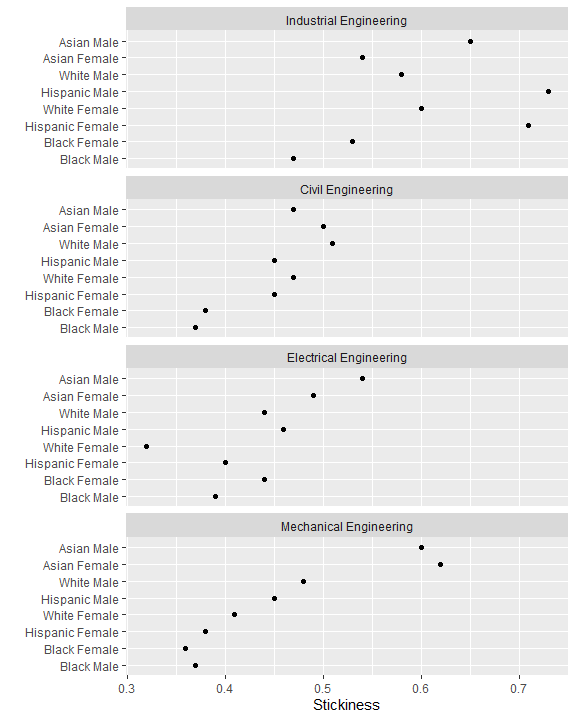

```r
# graph results
ggplot(data = data_mw, mapping = aes(x = stick, y = race_sex)) +
  facet_wrap(facets = vars(program), ncol = 1, as.table = FALSE) +
  geom_point(na.rm = TRUE) +
  labs(x = "Stickiness", y = "")
```

For more information on multiway data and interpreting multiway graphs, see the *Multiway graphs and tables* vignette (link).

## References

Ohland, Matthew, Orr, Marisa, Layton, Richard, et al. (2012) Introducing stickiness as a versatile metric of engineering persistence. In: *Proceedings of the Frontiers in Education Conference*, 2012, pp. 1–5.

## Appendix

### Complete script

The vignette code chunks are collected below in a single, condensed script.

```r
# packages used
library(midfieldr)
library(midfielddata)
library(data.table)
library(ggplot2)

# obtain programs (built-in data set)
program_group <- rep_group
group_cip <- program_group$cip6

# gather students ever enrolled in programs
cols_we_want <- c("id", "cip6")
rows_we_want <- midfieldterms$cip6 %in% group_cip
enrollees <- midfieldterms[rows_we_want, ..cols_we_want]
enrollees <- unique(enrollees)

# gather FYE students predicted to start in these programs
rows_we_want <- fye_start$start %in% group_cip
cols_we_want <- c("id", "start")
fye_starters <- fye_start[rows_we_want, ..cols_we_want]
fye_starters <- unique(fye_starters)
setnames(fye_starters, old = "start", new = "cip6")
enrollees <- rbind(enrollees, fye_starters)
enrollees <- unique(enrollees)

# apply the feasible completion filter
feasible_ids <- subset_feasible(id = enrollees$id)
rows_we_want <- enrollees$id %in% feasible_ids
enrollees <- enrollees[rows_we_want]

# obtain race/ethnicity and sex at matriculation
rows_we_want <- midfieldstudents$id %in% feasible_ids
cols_we_want <- c("id", "race", "sex")
race_sex <- midfieldstudents[rows_we_want, ..cols_we_want]
race_sex <- unique(race_sex)

# join data frames
enrollees <- merge(enrollees, race_sex, by = "id", all.x = TRUE)
enrollees <- merge(enrollees, program_group, by = "cip6", all.x = TRUE)

# gather students graduating from programs
cols_we_want <- c("id", "cip6", "term_degree")
rows_we_want <- midfielddegrees$cip6 %in% group_cip
graduates <- midfielddegrees[rows_we_want, ..cols_we_want]
graduates <- graduates[, .SD[term_degree == min(term_degree)], by = id]

# join race/ethnicity, sex, and program labels
rows_we_want <- midfieldstudents$id %in% graduates$id
cols_we_want <- c("id", "race", "sex")
race_sex <- midfieldstudents[rows_we_want, ..cols_we_want]
race_sex <- unique(race_sex)
graduates <- merge(graduates, race_sex, by = "id", all.x = TRUE)
graduates <- merge(graduates, program_group, by = "cip6", all.x = TRUE)

# group, summarize, and join
grouping_variables <- c("program", "race", "sex")
grouped_enrollees <- enrollees[, .(ever = .N), by = grouping_variables]
grouped_graduates <- graduates[, .(grad = .N), by = grouping_variables]
grouped_data <- merge(grouped_enrollees,
  grouped_graduates,
  by = grouping_variables,
  all.x = TRUE
)

# compute the metric
stickiness <- grouped_data
rows_with_degree_NA <- is.na(stickiness$grad)
stickiness[rows_with_degree_NA, grad := 0]
rows_we_want <- stickiness$ever > 0
stickiness <- stickiness[rows_we_want]
stickiness[, stick := round(grad / ever, 2)]

# condition the data in multiway form (built-in data set)
data_mw <- rep_stickiness_mw

# graph results
ggplot(data = data_mw, mapping = aes(x = stick, y = race_sex)) +
  facet_wrap(facets = vars(program), ncol = 1, as.table = FALSE) +
  geom_point(na.rm = TRUE) +
  labs(x = "Stickiness", y = "")
```